# Boolean (un)Satisfiability $\longleftrightarrow$ Graph Theory

Vaibhav Karve

(joint work with Anil Hirani)

**AWM Graduate Colloquium, 2019-02-20**

University of Illinois at Urbana-Champaign

## Who will go to the party?

[figure not shown]

## Who will go to the party?

1. Ant will definitely go if Bison goes.
2. Bison won't go if Cheetah goes.
3. Cheetah cannot go unless Dodo goes.
4. Bison and Dodo will go together or not at all.

## Three possible solutions:

1. Only **Ant** goes.
2. **Ant**, **Bison** and **Dodo** go.
3. No one goes. 🙁

## Who will go to the party?

1. Ant will definitely go if Bison goes.
2. Bison won't go if Cheetah goes.
3. Cheetah cannot go unless Dodo goes.
4. Bison and Dodo will go together or not at all.
5. **If the Ant goes, then the Cheetah must go.**

## Who will go to the party?

1. Ant will definitely go if Bison goes.
2. Bison won't go if Cheetah goes.
3. Cheetah cannot go unless Dodo goes.
4. Bison and Dodo will go together or not at all.
5. **If the Ant goes, then the Cheetah must go.**
6. **If the Dodo doesn't go, then the Ant must go.**

## How many constraints is too many?

## When is a party not happening?

## Boolean Satisfiability (SAT)

"When can we satisfy all the conditions?"

"When do the conditions become un-satisfiable?"

"Can we find an efficient algorithm to decide between the two?"

### Questions?

## Who cares about SAT?

Animal Kingdom party organizers

Stephen Cook & Leonid Levin  
(first NP-complete problem)

Computer scientists & Logicians

Aspirant millionaires (P vs. NP)

## Who else cares about SAT?

Graph theorists (graphists?)

- Find complete subgraphs
- Vertex cover problem
- Directed Hamiltonian cycle problem
- Undirected Hamiltonian cycle problem
- Graph coloring problem

Number theorists

- Partition problem
- Latin/Magic square problem

## Who else cares about SAT?

Gamers

- Super Mario Bros.
- Donkey Kong
- Pokemon
- Optimal Rubik's cube moves

Political Analysts

City Planners

Businesses

## Solving SAT is difficult

### "When you don't know the answer, change the question!"

## Modify the question

1. Ant will definitely go if Bison goes.
2. Bison won't go if Cheetah goes.
3. Cheetah cannot go unless Dodo goes.
4. Bison and Dodo will go together or not at all.

## Modify the question

1. Ant --------------------- Bison ----.
2. Bison ----------- Cheetah ----.
3. Cheetah ---------------- Dodo ----.
4. Bison --- Dodo ------------------------------.

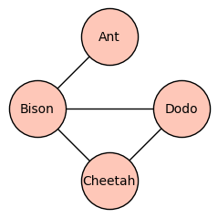

```python
Modified_Problem
```

## SAT $\longrightarrow$ Graph theory

### Animal kingdom party $\longmapsto$ Animal kingdom graph

## When is the party not happening? (*unsatisfiability*)

Complicated graph $\implies$ Unsatisfiable party

Sparse graph $\implies$ At least one solution exists

## Satisfiable graphs:

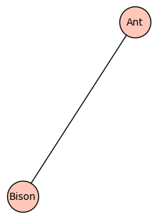

```python
Single_Edge
```

## Satisfiable graphs:

```python
Double_Edge
```

[output not shown]

## Satisfiable graphs:

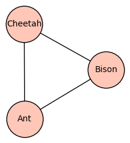

```python
Triangle
```

## Satisfiable graph:

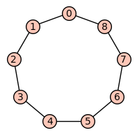

```python
Polygon
```

# How we looked for unsatisfiable graphs

### Lots of computer code

### Lots of graph operations

- Subgraphing
- Edge-deletion
- Vertex-deletion
- Edge-contractions
- Reduction of cycles
- Reduction of multi-edges

## Unsatisfiable graphs:

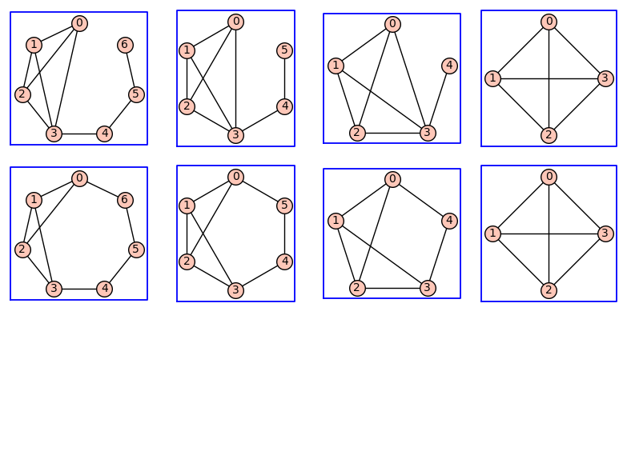

```python
Unsatisfiable_Family_1
```

## Unsatisfiable graphs:

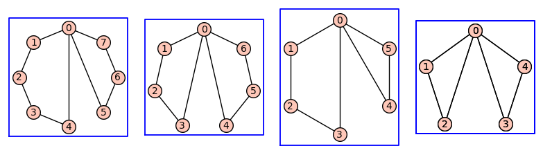

```python
Unsatisfiable_Family_2
```

## Unsatisfiable graphs:

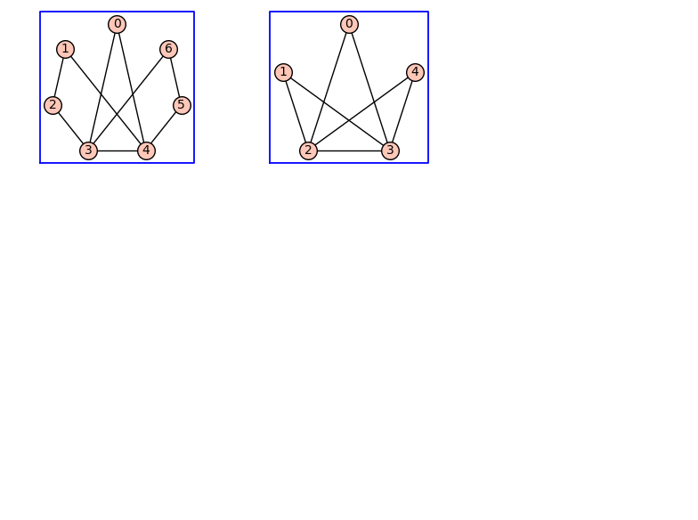

```python
Unsatisfiable_Family_3
```

# Main result

## The following graphs are obstructions to satisfiability:

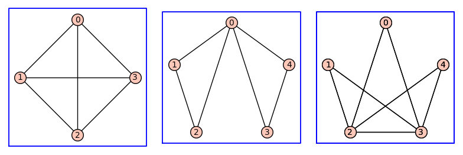

```python
Unsatisfiable_Graphs
```

# Main result

## The following graphs are obstructions to satisfiability:

[figure not shown]

## *Minimal criminals!*

# Links

- Wikipedia entry on Boolean satisfiability problem: en.wikipedia.org/wiki/Boolean_satisfiability_problem
- Wikipedia list of NP-complete problems: en.wikipedia.org/wiki/List_of_NP-complete_problems
- Our paper on arXiv: **The complete set of minimal simple graphs that support unsatisfiable 2-CNFs** arxiv.org/abs/1812.10849